# Project 2

# 1 Exploratory Data Analysis

## 1.1 Inspecting for trends and seasonality

```r
# For quickly formatting plots
my_theme <- theme(plot.title = element_text(hjust = 0.5, size = 16),
        axis.title = element_text(size = 12),
        axis.text = element_text(size = 12),
        plot.caption = element_text(size = 12, hjust = 0))
```

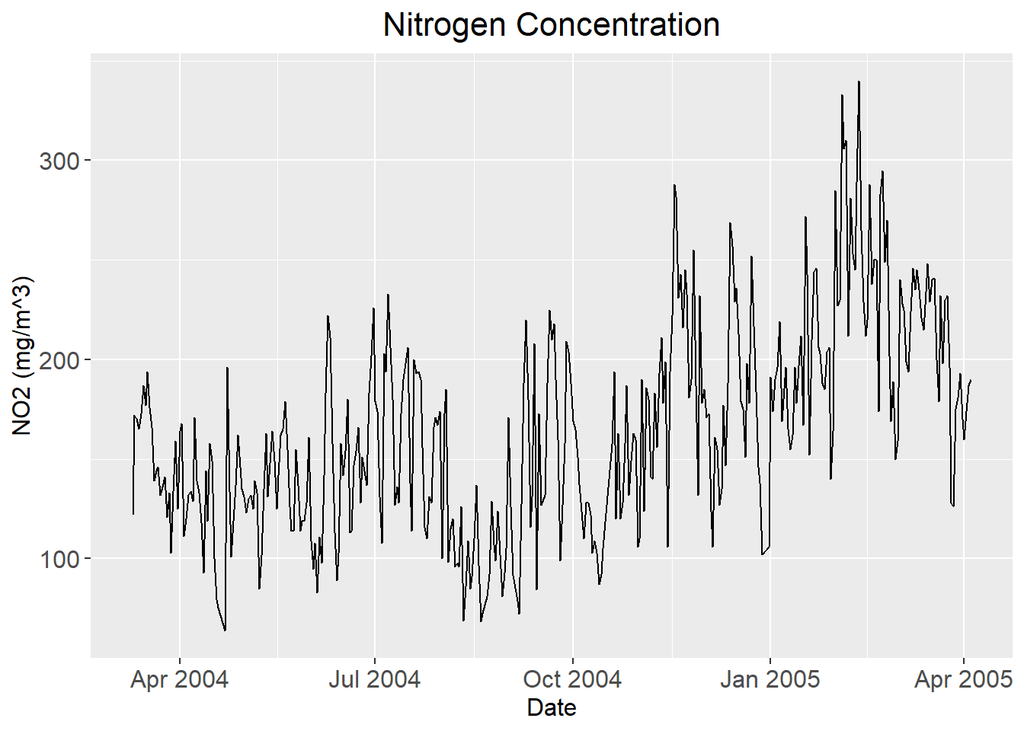

```r
dailyAQ %>% autoplot(NO2) + ylab("NO2 (mg/m^3)") + xlab("Date") +
  ggtitle("Nitrogen Concentration") + my_theme
```

The time series plot indicates potential seasonal components and a potential trend component.

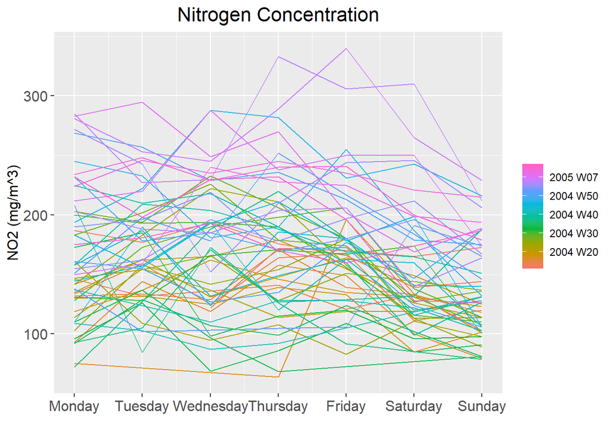

```r
dailyAQ %>% gg_season(NO2, period = "week") + ylab("NO2 (mg/m^3)") + xlab("") +
    ggtitle("Nitrogen Concentration") + my_theme
```

This plot indicates an increasing trend over time.

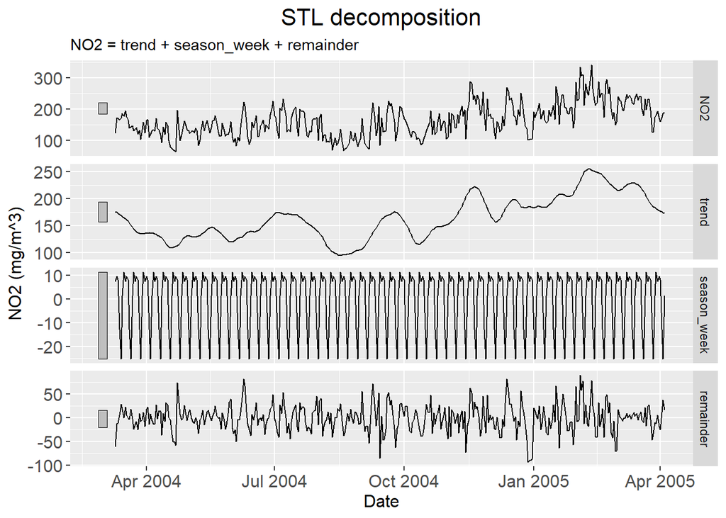

```r
dailyAQ %>% model(STL(NO2 ~ trend(window=21) + season(window = "periodic"), robust = TRUE)) %>%
  components() %>%autoplot() + my_theme + ylab("NO2 (mg/m^3)")
```

This seasonal decomposition chart shows a possibly increasing trend and a weekly seasonal component.

```r
pg.NO2 <- spec.pgram(NO2.ts,spans=9,demean=T,log='no')
```

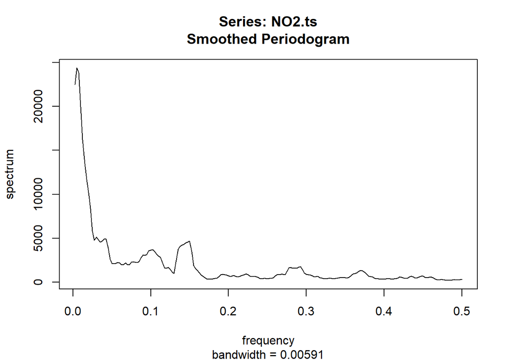

```r
spec.NO2 <- data.frame(freq=pg.NO2$freq, spec=pg.NO2$spec)

spec.NO2 <- data.frame(freq=pg.NO2$freq, spec=pg.NO2$spec) %>% mutate(period = 1/freq) %>% arrange(desc(spec))
spec.NO2[18, ]
```

```
##      freq     spec   period
## 18 0.1475 4579.926 6.779661
```

## 1.2 Hypotheses from exploratory data analysis:

# 2 Building Univariate Time Series Models

```r
# Creating potential predictors
dailyAQ <- dailyAQ %>% mutate(step = 1:length(Date)) %>%
      mutate(day = as.factor(as.character(lubridate::wday(Date, label  = TRUE)))) %>%
      mutate(weekend = isWeekend(Date))

# Create train and test sets
dailyAQ_train <- dailyAQ %>% head(n = length(Date) - 8)
dailyAQ_test <- dailyAQ %>% tail(n = 7)
```

## 2.1 Modeling trend and season

```r
# Create potential trend/season models
models <- dailyAQ_train %>%
  model(trend = TSLM(NO2 ~ trend()),
        trend_season_7 = TSLM(NO2 ~ trend() + sin(2*pi*step/7) + cos(2*pi*step/7)),
        trend_season_mnthly = TSLM(NO2 ~ trend() + sin(2*pi*step/(365.25/12)) + cos(2*pi*step/(365.25/12))),
        trend_season_w_wkday_dummy = TSLM(NO2 ~ trend() + day),
        trend_season_w_wknd_dummy = TSLM(NO2 ~ trend() + weekend))
```

```r
# Inspect the trend only model
models %>% dplyr::select(trend) %>% report()
## Series: NO2
## Model: TSLM
##
## Residuals:
##     Min      1Q  Median      3Q     Max
## -88.444 -33.593   2.634  28.304 138.425
##
## Coefficients:
##              Estimate Std. Error t value Pr(>|t|)
## (Intercept) 113.76664    4.51323   25.21   <2e-16 ***
## trend()       0.25902    0.02032   12.75   <2e-16 ***
## ---
## Signif. codes:  0 '***' 0.001 '**' 0.01 '*' 0.05 '.' 0.1 ' ' 1
##
## Residual standard error: 44.13 on 382 degrees of freedom
## Multiple R-squared: 0.2985,  Adjusted R-squared: 0.2966
## F-statistic: 162.5 on 1 and 382 DF, p-value: < 2.22e-16
```

The coefficient on trend is significant, and plotting the modeled trend line against the original data below verifies this.

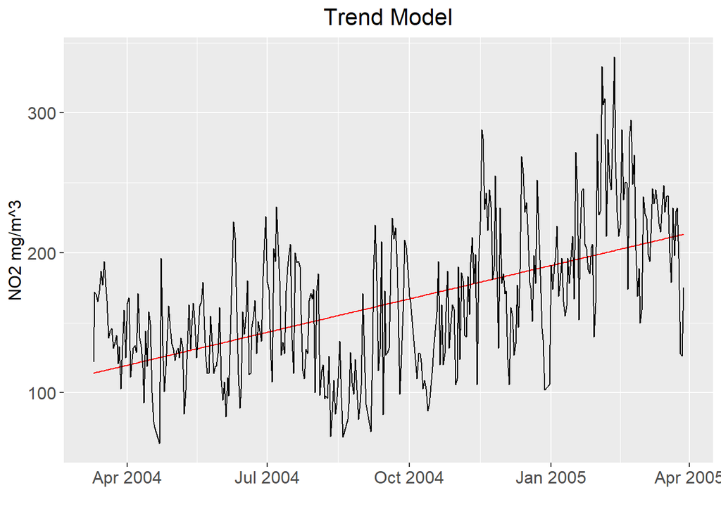

```r
models %>% dplyr::select(trend) %>% fitted() %>%
  autoplot(color = 'red') + autolayer(dailyAQ_train) +
        ggtitle("Trend Model") + ylab("NO2 mg/m^3") + xlab("") + my_theme
## Plot variable not specified, automatically selected `.vars = .fitted`
## Plot variable not specified, automatically selected `.vars = NO2`
```

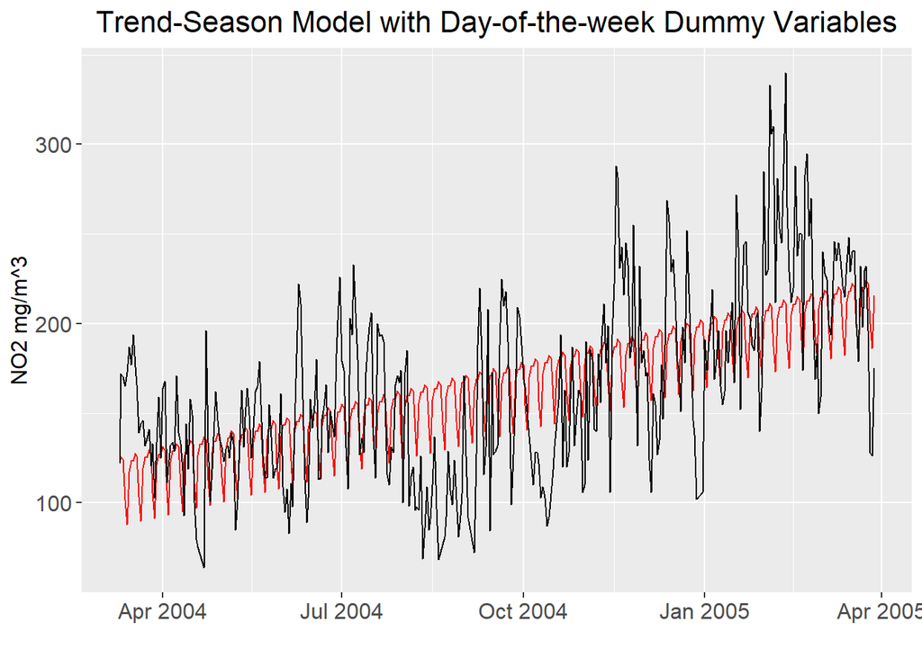

```r
models %>% dplyr::select(trend_season_w_wkday_dummy) %>% report()
## Series: NO2
## Model: TSLM
##
## Residuals:
##    Min     1Q Median     3Q    Max
## -99.28 -26.90   2.88  25.05 128.38
##
## Coefficients:
##             Estimate Std. Error t value Pr(>|t|)
## (Intercept) 123.4759     6.8287  18.082  < 2e-16 ***
## trend()       0.2600     0.0195  13.333  < 2e-16 ***
## dayMon       -7.6160     8.0767  -0.943  0.34630
## daySat      -22.7403     8.0765  -2.816  0.00512 **
## daySun      -36.9244     8.0765  -4.572 6.57e-06 ***
## dayThu        1.9389     8.0765   0.240  0.81041
## dayTue       -1.8427     8.1138  -0.227  0.82046
## dayWed       -1.9503     8.0765  -0.241  0.80931
## ---
## Signif. codes:  0 '***' 0.001 '**' 0.01 '*' 0.05 '.' 0.1 ' ' 1
##
## Residual standard error: 42.35 on 376 degrees of freedom
## Multiple R-squared: 0.3641,  Adjusted R-squared: 0.3523
## F-statistic: 30.75 on 7 and 376 DF, p-value: < 2.22e-16

models %>% dplyr::select(trend_season_w_wkday_dummy) %>% fitted() %>%
  autoplot(color = 'red') + autolayer(dailyAQ_train) +
        ggtitle("Trend-Season Model with Day-of-the-week Dummy Variables") + ylab("NO2 mg/m^3") + xlab("") + my_theme
## Plot variable not specified, automatically selected `.vars = .fitted`
## Plot variable not specified, automatically selected `.vars = NO2`
```

This model used a dummy variable for each day of the week. Friday is the base case. Only Saturday and Sunday were significantly different from the base case. NO2 concentrations on these days are lower. Perhaps traffic is heavier during the weekdays because of commuters. It is also notable that the trend term is still significant once the seasonality component has been accounted for.

Next we tried modeling the seasonal component with a single dummy variable indicating whether the date was on a weekday or weekend.

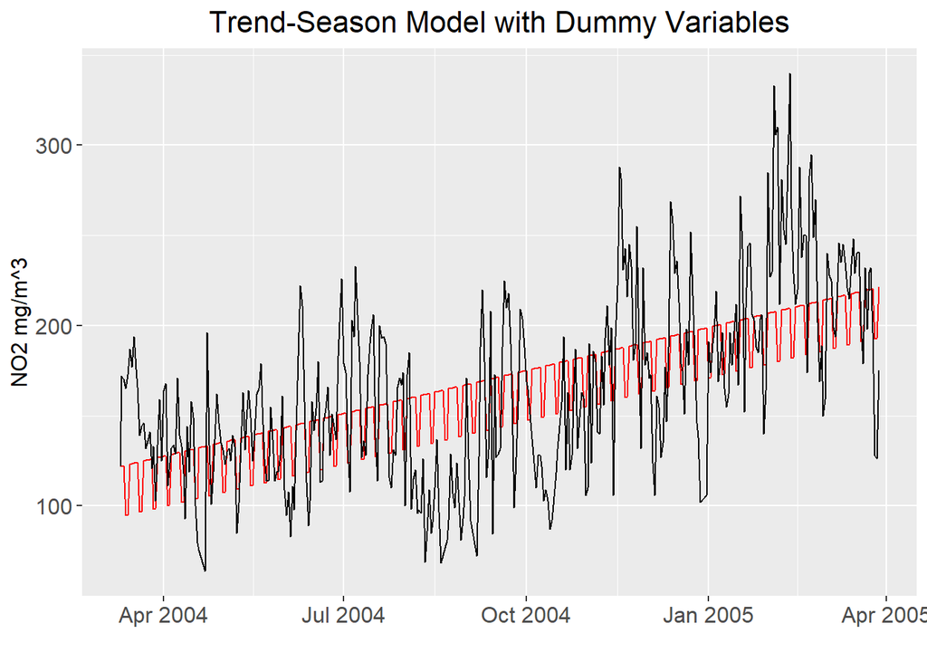

```r
models %>% dplyr::select(trend_season_w_wknd_dummy) %>% report()
## Series: NO2
## Model: TSLM
##
## Residuals:
##     Min      1Q  Median      3Q     Max
## -96.440 -27.579   2.535  26.753 130.327
##
## Coefficients:
##              Estimate Std. Error t value Pr(>|t|)
## (Intercept) 121.64424    4.53395  26.830  < 2e-16 ***
## trend()       0.25967    0.01949  13.324  < 2e-16 ***
## weekendTRUE -27.93766    4.77846  -5.847 1.08e-08 ***
## ---
## Signif. codes:  0 '***' 0.001 '**' 0.01 '*' 0.05 '.' 0.1 ' ' 1
##
## Residual standard error: 42.33 on 381 degrees of freedom
## Multiple R-squared: 0.3562,  Adjusted R-squared: 0.3529
## F-statistic: 105.4 on 2 and 381 DF, p-value: < 2.22e-16

models %>% dplyr::select(trend_season_w_wknd_dummy) %>% fitted() %>%
  autoplot(color = 'red') + autolayer(dailyAQ_train) +
        ggtitle("Trend-Season Model with Dummy Variables") + ylab("NO2 mg/m^3") + xlab("") + my_theme
## Plot variable not specified, automatically selected `.vars = .fitted`
## Plot variable not specified, automatically selected `.vars = NO2`
```

All coefficients are significant indicating this is a strong candidate model.

The models reported in the summary and plot below had trigonometric functions to model 7 day and 30 day seasonal components.

```r
models %>% dplyr::select(trend_season_7, trend_season_mnthly) %>% coef()
```

```
## # A tibble: 8 x 6
##   .model           term                    estimate std.error statistic  p.value
##   <chr>            <chr>                      <dbl>     <dbl>     <dbl>    <dbl>
## 1 trend_season_7   (Intercept)              114.       4.37      26.0   3.28e-86
## 2 trend_season_7   trend()                    0.260    0.0197    13.2   4.27e-33
## 3 trend_season_7   sin(2 * pi * step/7)      14.9      3.08       4.84  1.91e- 6
## 4 trend_season_7   cos(2 * pi * step/7)       5.84     3.09       1.89  5.97e- 2
## 5 trend_season_mn~ (Intercept)              113.       4.48      25.3   1.34e-83
## 6 trend_season_mn~ trend()                    0.260    0.0202    12.9   1.07e-31
## 7 trend_season_mn~ sin(2 * pi * step/(365~    8.83     3.17       2.79  5.62e- 3
## 8 trend_season_mn~ cos(2 * pi * step/(365~   -0.800    3.15      -0.254 8.00e- 1
```

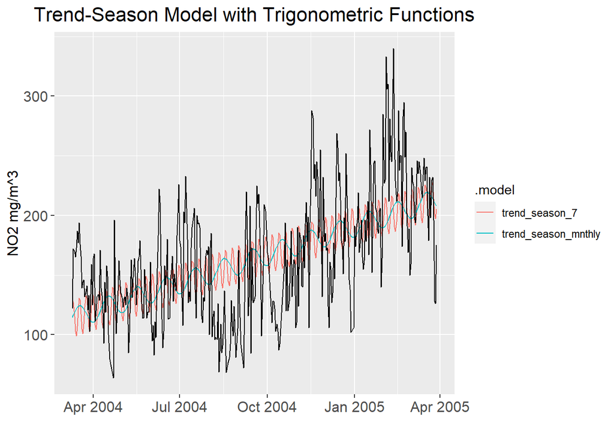

```r
models %>%
  dplyr::select(trend_season_7, trend_season_mnthly) %>%
  fitted() %>% autoplot() +
  autolayer(dailyAQ_train) +
  ggtitle("Trend-Season Model with Trigonometric Functions") +
  ylab("NO2 mg/m^3") + xlab("") + my_theme
## Plot variable not specified, automatically selected `.vars = .fitted`
## Plot variable not specified, automatically selected `.vars = NO2`
```

The 7-day period functions produce more significant coefficients indicating that a weekly trend is more significant than an approximately monthly trend.

To decide which is the best approach, we compared performance metrics across the candidate models with a trend and seasonal component.

```r
models %>%
  dplyr::select(trend_season_7, trend_season_mnthly,
         trend_season_w_wkday_dummy, trend_season_w_wknd_dummy) %>%
  report() %>% dplyr::select(.model, adj_r_squared, AIC, BIC, df.residual)
```

[output not shown]

We decided to stick choose the first, third, and fourth model for the remainder of the analysis.

## 2.2 Modeling the residuals of best trend/season models

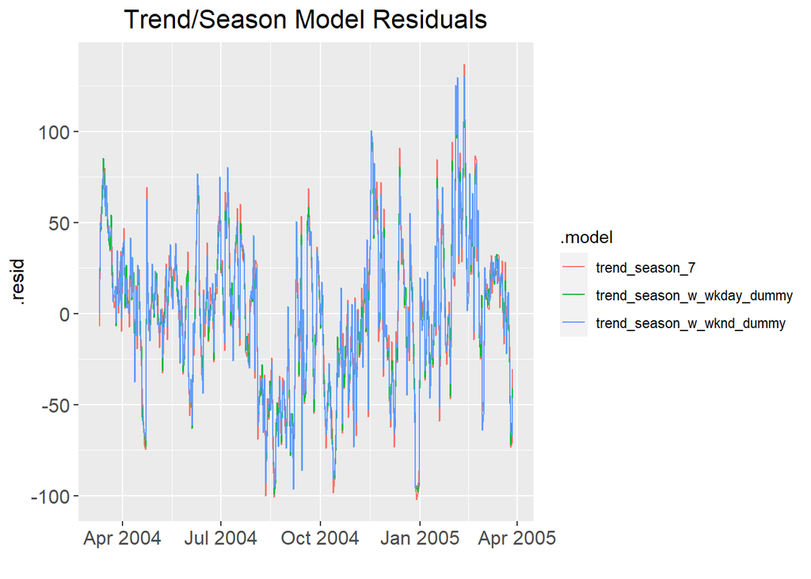

```r
# Extract model residuals
data_resids <- models %>%
  dplyr::select(trend_season_7, trend_season_w_wkday_dummy, trend_season_w_wknd_dummy) %>%
  residuals()

# Plot the residuals
data_resids %>% autoplot(.resid) + ggtitle("Trend/Season Model Residuals") +
  xlab("") +  my_theme
```

There is clearly some autocorrelation in the residuals.

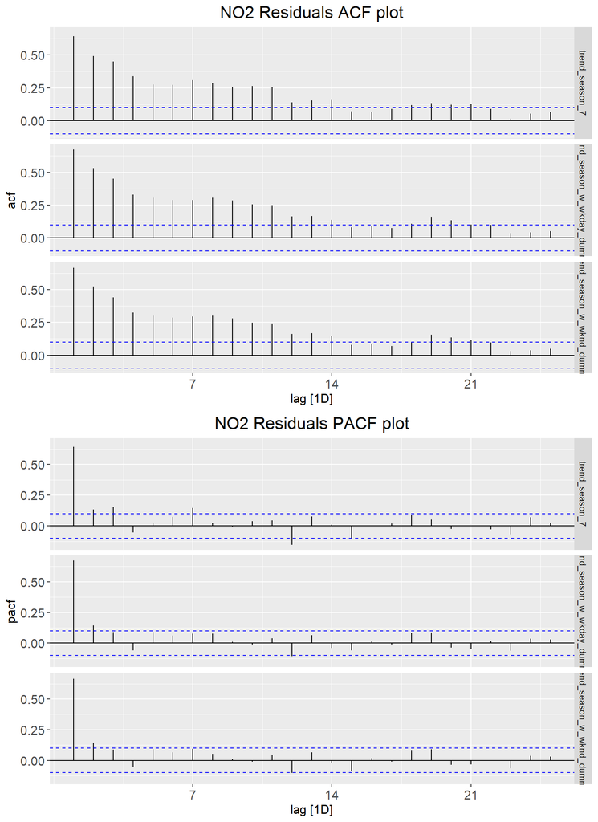

```r
plt_resid_ACF <- data_resids %>%
  # dplyr::filter(.model == 'trend_season_w_wknd_dummy') %>%
  ACF(.resid) %>% autoplot() + ggtitle("NO2 Residuals ACF plot") + my_theme

plt_resid_PACF <- data_resids %>%
  # dplyr::filter(.model == 'trend_season_w_wknd_dummy') %>%
  PACF(.resid) %>% autoplot() + ggtitle("NO2 Residuals PACF plot") + my_theme

ggarrange(plt_resid_ACF,plt_resid_PACF,nrow=2,ncol=1)
```

All three models exhibit similar behavior in the ACF and PACF. There is sinusoidal decay in the ACF of the residuals. The PACF could be interpreted as cutting off after lag 2 or as exhibiting sinusoidal behavior. This indicates that the residuals could be modeled as either AR(2) or as an ARMA process.

```r
# Model the residuals
models_residuals <- data_resids %>%
  rename("model" = ".model", "resid" = ".resid") %>%
  model(auto.arima = ARIMA(resid ~ PDQ(0,0,0)),
        ar2 = ARIMA(resid ~ pdq(2, 0, 0) + PDQ(0,0,0)))
# Show the pdq values from the auto.arima models
models_residuals %>% tidy() %>% filter(.model == 'auto.arima')
```

```
## # A tibble: 9 x 7
##   model                    .model    term  estimate std.error statistic  p.value
##   <chr>                    <chr>     <chr>    <dbl>     <dbl>     <dbl>    <dbl>
## 1 trend_season_7           auto.ari~ ar1      1.28      0.141      9.07 6.39e-18
## 2 trend_season_7           auto.ari~ ar2     -0.329     0.111     -2.96 3.25e- 3
## 3 trend_season_7           auto.ari~ ma1     -0.750     0.121     -6.19 1.51e- 9
## 4 trend_season_w_wkday_du~ auto.ari~ ar1      1.33      0.144      9.22 1.97e-18
## 5 trend_season_w_wkday_du~ auto.ari~ ar2     -0.375     0.115     -3.25 1.25e- 3
## 6 trend_season_w_wkday_du~ auto.ari~ ma1     -0.763     0.124     -6.17 1.74e- 9
## 7 trend_season_w_wknd_dum~ auto.ari~ ar1      1.32      0.139      9.49 2.52e-19
## 8 trend_season_w_wknd_dum~ auto.ari~ ar2     -0.369     0.111     -3.31 1.01e- 3
## 9 trend_season_w_wknd_dum~ auto.ari~ ma1     -0.764     0.119     -6.41 4.39e-10
```

The auto-selection process yielded ARMA(2, 1) models for each set of residuals.

```r
# Compare AIC and BIC across the models
models_residuals %>% report() %>%
  dplyr::select(model, .model, AIC, BIC)
```

[output not shown]

For each set of residuals, the ARMA(2, 1) model had the lowest AIC but the AR(2) model had the lowest BIC probably because it has fewer terms.

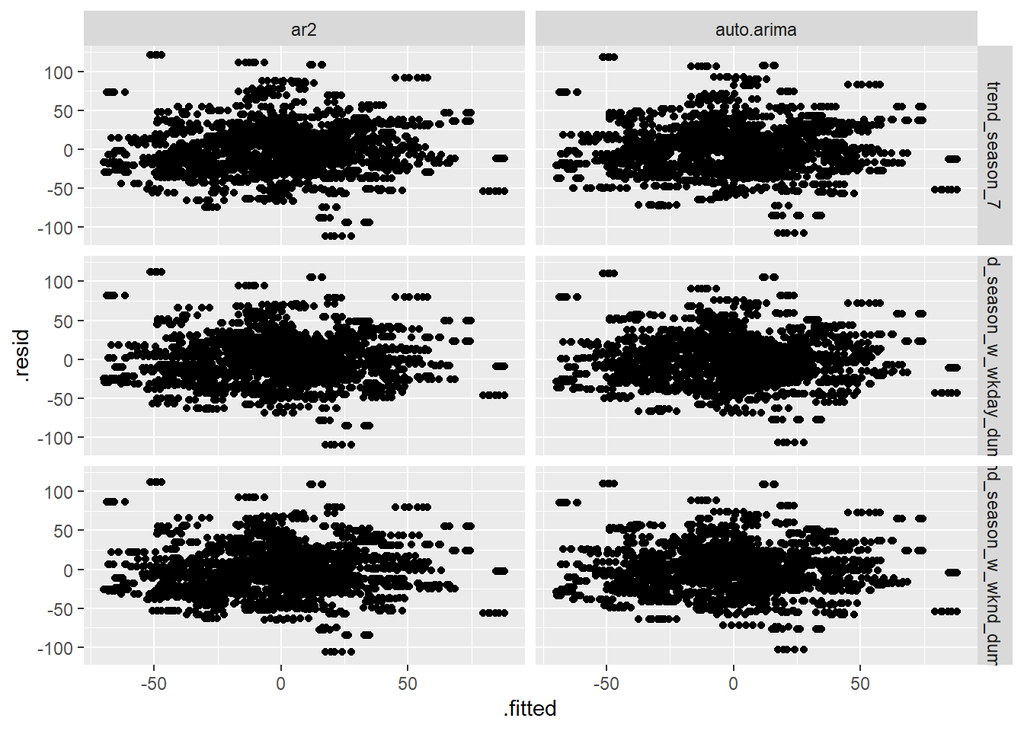

```r
# Plot residuals vs. fitted
models_residuals_fitted <-
  models_residuals %>% fitted() %>% as_tibble() %>% dplyr::select(Date, '.fitted')

models_residuals_resid <-
  models_residuals %>% residuals() %>% as_tibble()

model_residuals_fittedAndResiduals <-
  inner_join(models_residuals_resid, models_residuals_fitted, by = "Date")

ggplot(model_residuals_fittedAndResiduals, aes(.fitted, .resid)) +
    geom_point() + facet_grid(rows = vars(model), cols = vars(.model))
```

There is no clear trend in the residuals for any residual data/model combination.

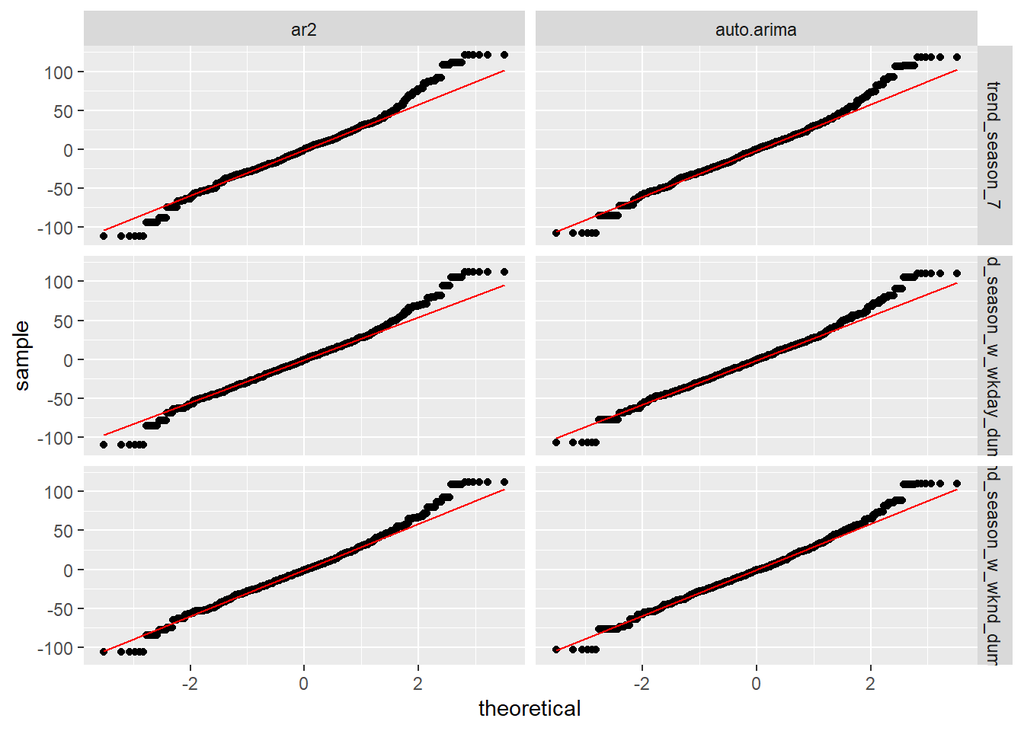

```r
# Plot QQ plots
ggplot(model_residuals_fittedAndResiduals, aes(sample = .resid)) +
    stat_qq() + stat_qq_line(color = "red") +
    facet_grid(rows = vars(model), cols = vars(.model))
```

The residuals for each model all appear to exhibit similar patterns and are approximately gaussian with some fat-tail behavior.

# 3 Forecasting

## 3.1 Residuals forecasting

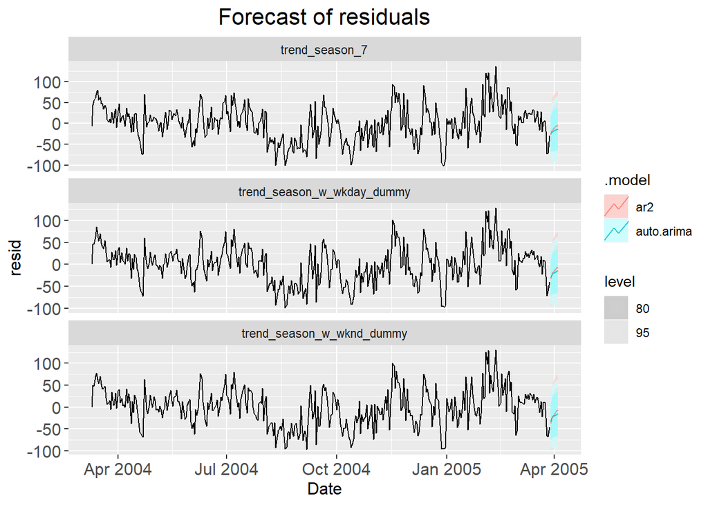

```r
resid_summary <- models_residuals %>% augment()

resid_7day_forecast <- models_residuals %>%
  forecast(h = "1 week")

plt_resid_forecast <- resid_7day_forecast %>% feasts::autoplot(alpha = 0.8) +
  geom_line(data = resid_summary, aes(x = Date, y = resid)) +
  ggtitle("Forecast of residuals") + my_theme

plt_resid_forecast
```

```r
resid_7day_forecast <- resid_7day_forecast %>% hilo(level = 95)
```

The forecast of residuals look reasonable and very similar for each model but the confidence interval on the auto.arima model which is ARMA(2, 1) appears tighter.

## 3.2 Season/trend forecasting

```r
main_summary <- models %>% select(trend_season_w_wknd_dummy, trend_season_w_wkday_dummy, trend_season_7) %>% augment()

main_7day_forecast <- models %>%
  select(trend_season_w_wknd_dummy, trend_season_w_wkday_dummy, trend_season_7) %>%
  forecast(new_data = dailyAQ_test)
```

## 3.3 Combining Season/trend and residuals forecasts and computing MSE

```r
full_model_summary <- resid_summary %>%
  left_join(main_summary,
            by = c("Date" = "Date", "model" = ".model"),
            suffix = c(".resid", ".full"))

full_forecast <- left_join(resid_7day_forecast, main_7day_forecast,
                           by = c("model" = ".model", "Date" = "Date"),
                           suffix = c(".resid", ".full")) %>%
                mutate(pt_pred = .mean.resid + .mean.full)

test_data <- dailyAQ_test %>%
  dplyr::select(Date, "NO2") %>%
  rename("NO2_Actual" = "NO2")

full_forecast <- full_forecast %>% inner_join(test_data, by = ("Date" = "Date"))

forecast_MSE <- full_forecast %>% as_tibble() %>% group_by(model, .model) %>%
  mutate(sqrd_error = (pt_pred - NO2_Actual)^2) %>% summarize(MSE = mean(sqrd_error))
## `summarise()` regrouping output by 'model' (override with `.groups` argument)
```

## 3.4 Ploting forecasts and MSE

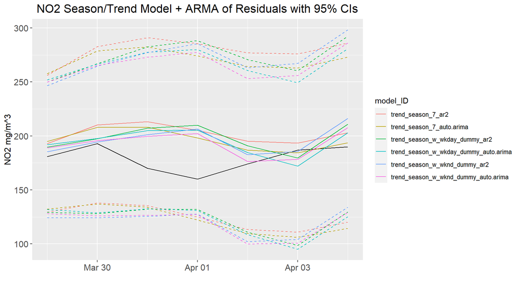

```r
full_forecast <- full_forecast %>% unpack_hilo(cols = "95%") %>%
  mutate(`95%_upper` = .mean.full + `95%_upper`) %>%
  mutate(`95%_lower` = .mean.full + `95%_lower`) %>%
  mutate(model_ID = paste(model, .model, sep = "_"))

plot_forecasts <- ggplot(data = full_forecast, aes(group = model_ID, color = model_ID)) +
  geom_line(aes(x=Date,y=NO2_Actual), color = "black") +
  geom_line(aes(x=Date,y=pt_pred)) +
  geom_line(aes(x=Date,y=`95%_lower`),linetype="dashed") +
  geom_line(aes(x=Date,y=`95%_upper`),linetype="dashed") +
  xlab("") + ylab("NO2 mg/m^3") +
  ggtitle("NO2 Season/Trend Model + ARMA of Residuals with 95% CIs") + my_theme

plot_forecasts
```

```r
forecast_MSE
```

```
## # A tibble: 6 x 3
## # Groups:   model [3]
##   model                      .model       MSE
##   <chr>                      <chr>      <dbl>
## 1 trend_season_7             ar2         718.
## 2 trend_season_7             auto.arima  504.
## 3 trend_season_w_wkday_dummy ar2         681.
## 4 trend_season_w_wkday_dummy auto.arima  562.
## 5 trend_season_w_wknd_dummy  ar2         560.
## 6 trend_season_w_wknd_dummy  auto.arima  448.
```

The plot comparing test set prediction performance across each trend/season and residual model combination fails to clearly show which model is best. However, the mean squared error indicates that the auto.arima models - ARMA(2,1) - are best across the board for modeling residuals. The best trend/season model appears to the one with weekend dummy variables.